# Analyzing the Conflict Between Industrial Growth (SDG 9) and Climate Action (SDG13)

Dorothy Worbie

# Executive Summary

1. Initial analysis of this data revealed a strong negative correlation between Innovation (SDG 9) and Climate Action (SDG 13). However, through multiple regression modeling, the final analysis concluded that this trade-off is misleading. The negative effect of SDG 9 disappears when controlling for Unsustainable Consumption (SDG 12) and Sustainable Cities (SDG 11).

# 1. Data Preparation and Initial Exploration

*1.1 Data Source and Initial Preparation*

This dataset, originally sourced as a **.xlsx file from the Sustainable Development Report website, underwent initial cleaning and preparation in Microsoft Excel. This involved removing duplicate entries, ensuring consistent data formatting and correcting typographical errors. Additionally, minor descriptive statistical analysis was performed in Excel to gain a foundational understanding of the data structure. The current file imported into R is a pre-processed version, and all other subsequent in-depth statistical analysis, modelling and visualizations will be done using R.

*1.2 Installing packages and loading libraries*

```r
#install.packages("tidyverse")
# install.packages("readxl")
# install.packages("ppcor")
# install.packages("car")

library(tidyverse)
library(ggplot2)
library(ppcor)
library(car)
library(dplyr)
```

*1.3 Importing & Cleaning*

```r
# Reading the dataset
Correlation.Data <- read.csv("/Users/D./Downloads/Correlation Data.csv", header = TRUE)

sdg_data <- read.csv("/Users/D./Downloads/Correlation Data.csv", header = TRUE)

sdg_data <- Correlation.Data

# Inspecting the first few rows and structure to confirm successful import

# View(sdg_data)  # Commented out for smooth  knitting

str(sdg_data)
```

[output not shown]

```r
head(sdg_data)
```

```
##                Country goal9 goal13
## 1          Afghanistan    14     99
## 2               Angola    20     94
## 3              Albania    43     88
## 4              Andorra    62     87
## 5 United Arab Emirates    83     10
## 6            Argentina    50     90
```

```r
# Data import and removing NA values

sdg_analysis <- sdg_data %>%

  # Remov NAs first
  na.omit() %>%

  # 1. Renaming the original columns (goal9, goal13) to the clean names (sdg_9, sdg_13)
  # Force R to use the dplyr::rename function (this was done to prevent multiple error messages)
  dplyr::rename(sdg_9 = goal9,
                sdg_13 = goal13) %>%

  # 2. Select and reorder the final columns (using the NEW names)
  # Force R to use the dplyr::select function

  dplyr::select(Country, sdg_9, sdg_13)
```

*1.4 Exploratory Data Analysis (EDA)*

Visual Inspection (Histograms) - justify the choice of a non-parametric test (Spearman’s ρ).

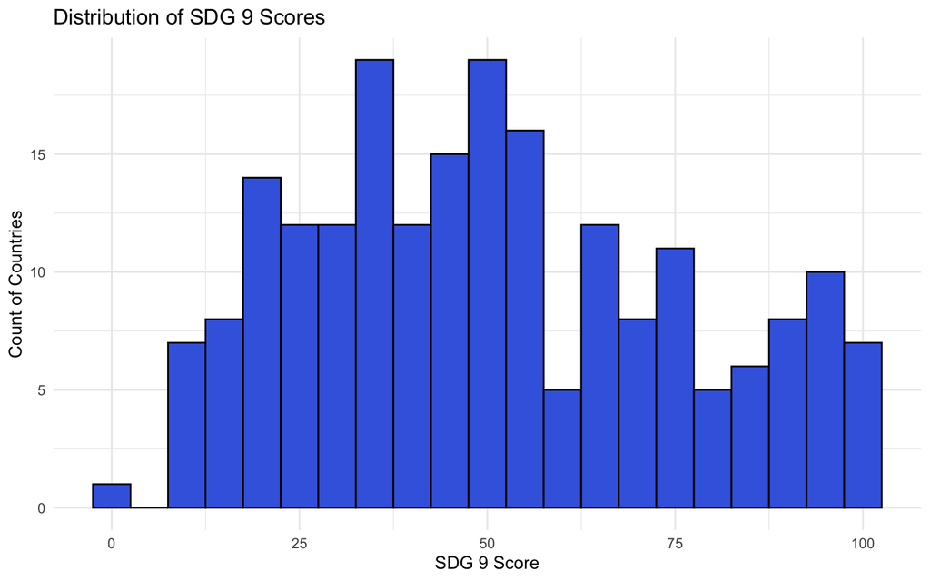

```r
# Distribution of SDG 9 scores (Outlier/Skewness Check)

ggplot(sdg_analysis, aes(x = sdg_9)) +
  geom_histogram(binwidth = 5, fill = "#4169E1", color = "black") +
  labs(
    title = "Distribution of SDG 9 Scores",
    x = "SDG 9 Score",
    y = "Count of Countries"
  ) +
  theme_minimal()
```

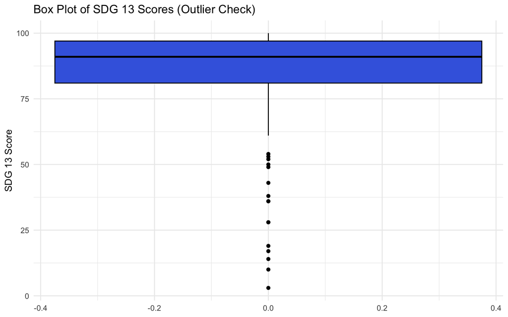

```r
# Box plot for SDG 13 to identify specific outliers

ggplot(sdg_analysis, aes(y = sdg_13)) +
  geom_boxplot(fill = "#4169E1", color = "black") +
  labs(
    title = "Box Plot of SDG 13 Scores (Outlier Check)",
    y = "SDG 13 Score"
  ) +
  theme_minimal()
```

*Observation:* The skewed distribution (especially for SDG 13) proves the importance of using Spearman’s Rank Correlation as a better option for focus on ranks instead of raw numbers, for data reliability (in this case with messy data and extreme outliers).

# 2. Correlational Analysis and Reliability

*2.1 Calculating and Testing Spearman’s ρ*

```r
# Formally testing the Spearman's rank correlation coefficient (ρ)

spearman_test_result <- cor.test(sdg_analysis$sdg_9,
                                  sdg_analysis$sdg_13,
                                  method = "spearman",
                                  exact = FALSE)

print(spearman_test_result)
```

```
##
##  Spearman's rank correlation rho
##
## data:  sdg_analysis$sdg_9 and sdg_analysis$sdg_13
## S = 2655359, p-value < 2.2e-16
## alternative hypothesis: true rho is not equal to 0
## sample estimates:
##        rho
## -0.7962785
```

*2.2 Visualizing the Rank Relationship*

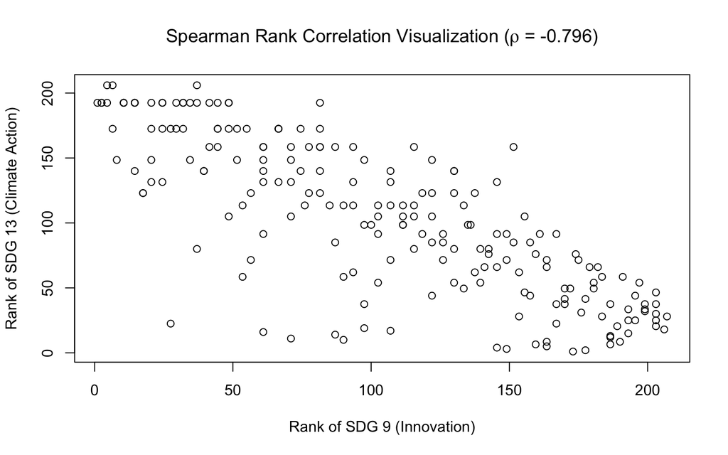

```r
plot(rank(sdg_analysis$sdg_9), rank(sdg_analysis$sdg_13),
     main = expression(paste("Spearman Rank Correlation Visualization (", rho, " = -0.796)")),
     xlab = "Rank of SDG 9 (Innovation)",
     ylab = "Rank of SDG 13 (Climate Action)")
```

*2.3 Data Reliability Check (Kendall’s τ)*

```r
# Confirming robustness using the alternative non-parametric coefficient, Kendall's Tau (τ)
kendall_test <- cor.test(sdg_analysis$sdg_9,
                         sdg_analysis$sdg_13,
                         method = "kendall")

print(kendall_test)
```

```
##
##  Kendall's rank correlation tau
##
## data:  sdg_analysis$sdg_9 and sdg_analysis$sdg_13
## z = -13.051, p-value < 2.2e-16
## alternative hypothesis: true tau is not equal to 0
## sample estimates:
##        tau
## -0.6240675
```

# 3. Investigating Confounding Variables

Investigating granular drivers like SDG Goals 7, 11, etc. for further investigation.

*3.1 Merging and Ordering the Full Dataset*

```r
# Loading the second dataset containing sdg_6, sdg_7, sdg_11, sdg_12 and merging to previous dataframe used for earlier analysis

new_sdg_data <- read.csv("/Users/D./Downloads/New correlation data.csv", header = TRUE)

sdg_analysis_merged <- merge(
    x = sdg_analysis,
    y = new_sdg_data,
    by = "Country",
    all.x = FALSE
)

# Checking first few rows
head(sdg_analysis_merged)
```

```
##               Country sdg_9 sdg_13 sdg_6 sdg_7 sdg_11 sdg_12
## 1         Afghanistan    14     99    51    34     34     95
## 2             Albania    43     88    83    87     90     77
## 3             Algeria    46     90    59    67     70     88
## 4             Andorra    62     87   100    77     99     30
## 5              Angola    20     94    55    46     42     94
## 6 Antigua and Barbuda    61     83    82    67     98     73
```

```r
# Assigning the final, processed data frame to sdg_analysis_cleaned

sdg_analysis_cleaned <- sdg_analysis_merged %>%

  # 1. Cleaning the data to remove NA rows resulting from the merge
  na.omit() %>%

  # 2. Arranging the columns in  order for easy readability
  dplyr::select(
    Country,
    sdg_6,
    sdg_7,
    sdg_9,
    sdg_11,
    sdg_12,
    sdg_13
  )

# Confirming the cleaned dataframe
head(sdg_analysis_cleaned)
```

```
##               Country sdg_6 sdg_7 sdg_9 sdg_11 sdg_12 sdg_13
## 1         Afghanistan    51    34    14     34     95     99
## 2             Albania    83    87    43     90     77     88
## 3             Algeria    59    67    46     70     88     90
## 4             Andorra   100    77    62     99     30     87
## 5              Angola    55    46    20     42     94     94
## 6 Antigua and Barbuda    82    67    61     98     73     83
```

*3.2 Partial Correlation (Controlling for SDG 11)*

The rationale is to use the SDG_11 as a proxy for infrastructural/development to verify if the conflict is simply due to wealth.

```r
# Calculate the Spearman partial correlation (SDG 9 vs. SDG 13, controlling for SDG 11)
partial_rho_11 <- pcor.test(sdg_analysis_cleaned$sdg_9,
                            sdg_analysis_cleaned$sdg_13,
                            sdg_analysis_cleaned$sdg_11,
                            method = "spearman")

print(partial_rho_11)
```

```
##     estimate      p.value statistic   n gp   Method
## 1 -0.6467123 1.137069e-25 -12.08053 206  1 spearman
```

*3.3 Granular Correlation Matrix*

Rationale is to identify which goals have the strongest relationships with the main variables (SDG 9 & SDG 13).

```r
# Creating a Subset of the data for the six relevant goals

sdg_subset <- sdg_analysis_cleaned[, c("sdg_6", "sdg_7", "sdg_9", "sdg_11", "sdg_12", "sdg_13")]

# Calculating  the Spearman correlation matrix

cor_matrix <- cor(sdg_subset, method = "spearman", use = "complete.obs")

print(cor_matrix)
```

```
##             sdg_6      sdg_7      sdg_9     sdg_11     sdg_12     sdg_13
## sdg_6   1.0000000  0.7946536  0.7465067  0.7084638 -0.7342945 -0.6657148
## sdg_7   0.7946536  1.0000000  0.7417225  0.6584296 -0.7290929 -0.6378758
## sdg_9   0.7465067  0.7417225  1.0000000  0.6579118 -0.8474378 -0.7955778
## sdg_11  0.7084638  0.6584296  0.6579118  1.0000000 -0.7415445 -0.6411449
## sdg_12 -0.7342945 -0.7290929 -0.8474378 -0.7415445  1.0000000  0.8761055
## sdg_13 -0.6657148 -0.6378758 -0.7955778 -0.6411449  0.8761055  1.0000000
```

# 4. Final Causal Quantification (Multiple Linear Regression)

*4.1 Building the Final Model*

The goal of the final model is to see if the negative link between SDG 9 (Innovation) and SDG 13 (Climate Action) is fake (misleading).

```r
# Building the model: SDG 13 explained by SDG 9, SDG 12, and SDG 11
final_model <- lm(sdg_13 ~ sdg_9 + sdg_12 + sdg_11,
                  data = sdg_analysis_cleaned)

summary(final_model)
```

```
##
## Call:
## lm(formula = sdg_13 ~ sdg_9 + sdg_12 + sdg_11, data = sdg_analysis_cleaned)
##
## Residuals:
##     Min      1Q  Median      3Q     Max
## -49.133  -2.357   1.919   5.990  40.885
##
## Coefficients:
##             Estimate Std. Error t value Pr(>|t|)
## (Intercept) -0.90200   12.11172  -0.074 0.940707
## sdg_9       -0.04784    0.06200  -0.772 0.441301
## sdg_12       0.91768    0.09991   9.185  < 2e-16 ***
## sdg_11       0.22680    0.06600   3.436 0.000716 ***
## ---
## Signif. codes:  0 '***' 0.001 '**' 0.01 '*' 0.05 '.' 0.1 ' ' 1
##
## Residual standard error: 12.61 on 202 degrees of freedom
## Multiple R-squared:  0.5263, Adjusted R-squared:  0.5193
## F-statistic: 74.82 on 3 and 202 DF,  p-value: < 2.2e-16
```

*4.2 Visualizing Final Model Coefficients (Statistical Significance)*

This plot visually represents the final proof that shows which variables are real problems for the climate and which ones are not.

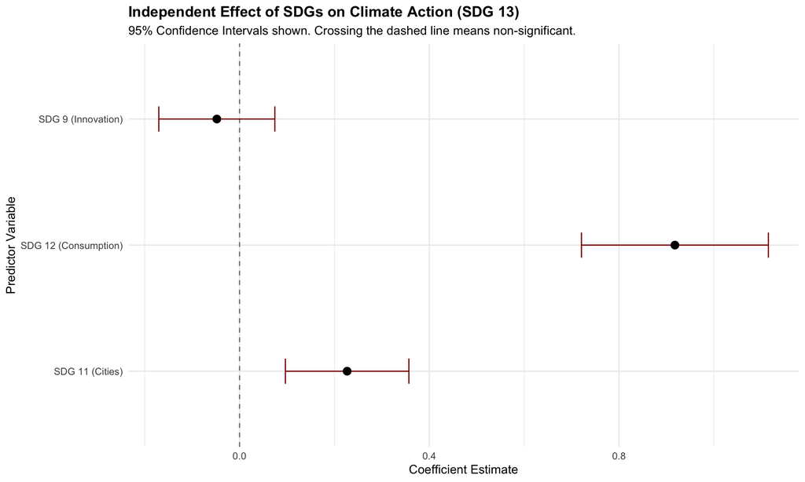

```r
# Extracting and calculating CIs using the built-in confint() function

model_summary <- as.data.frame(summary(final_model)$coefficients)
model_summary$Predictor <- rownames(model_summary)

# Calculating  95% Confidence Intervals

conf_intervals <- confint(final_model)
model_summary$Lower_CI <- conf_intervals[, 1]
model_summary$Upper_CI <- conf_intervals[, 2]

# Filtering out the intercept for cleaner plotting

model_data <- model_summary[-1, ]

# Creating the visualization
coef_plot <- ggplot(model_data, aes(x = Estimate, y = Predictor)) +
  geom_vline(xintercept = 0, linetype = "dashed", color = "gray50") +
  geom_errorbarh(aes(xmin = Lower_CI, xmax = Upper_CI),
                 height = 0.2, color = "darkred") +
  geom_point(size = 3, color = "black") +
  scale_y_discrete(labels = c(
    "sdg_9" = "SDG 9 (Innovation)",
    "sdg_12" = "SDG 12 (Consumption)",
    "sdg_11" = "SDG 11 (Cities)"
  )) +
  labs(
    title = "Independent Effect of SDGs on Climate Action (SDG 13)",
    subtitle = "95% Confidence Intervals shown. Crossing the dashed line means non-significant.",
    x = "Coefficient Estimate",
    y = "Predictor Variable"
  ) +
  theme_minimal() +
  theme(plot.title = element_text(face = "bold"))

print(coef_plot)
```

## 4.3 Partial Residual Plots

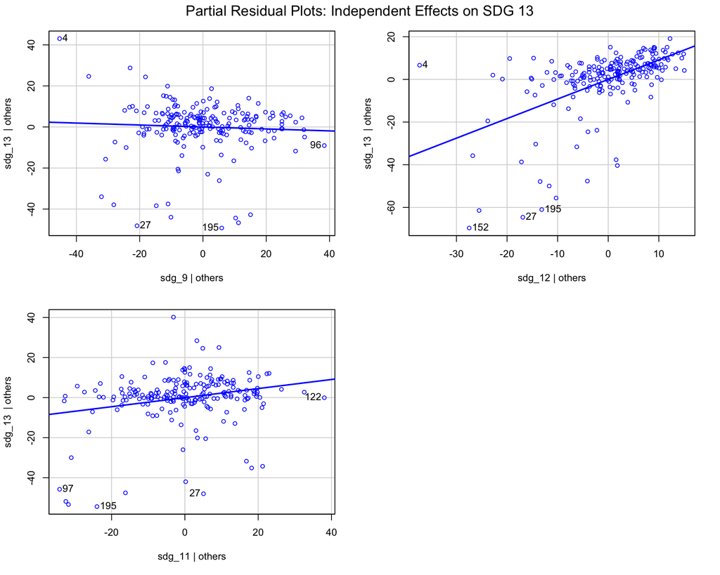

```r
# Generate partial residual plots for all predictors in the model

car::avPlots(final_model,
             main = "Partial Residual Plots: Independent Effects on SDG 13",
             col = "blue")
```